# R Mini Project 2: R Script Covering Data Frames, Vectors, and Strings

Thinh Le

2024-10-03

# Background

Undergraduate students enrolled in Biodiversity and Evolution (BIOL1400) at Stockton University during the Fall 2021 & 2023 and Spring 2021 semesters were tasked with the assignment to document 20-30 different species of life using citizen science platform, iNaturalist. iNaturalist is an online social network that helps you identify the plants and animals around you while generating data for science and conservation. You can use it to record your own observations, get help with identifications, or collaborate with others.

The taxonomic system for species classification is composed of Kingdom, Phylum, Class, Order, Family, Genus, species. For example, humans are classified as Animalia, Chordata, Mammalia, Primates, Hominidae, Homo, sapiens.

Link to the project summary on iNaturalist. For this dataset, only Research grade observations have been selected. Research grade means the species identification has been verified by one or more other users on iNaturalist. Research grade also ensures that all observations of taxa are wild. No Casual grade observations from zoos, aquariums, or manmade gardens are included.

# Instructions

Write an R script with inline comments that successfully:

- Write your name, date, and assignment at the top
- Loads all necessary libraries
- Reads in the data
- Describes the data using:
  - At a minimum - head(), glimpse(), summary(), and str()
  - Other unique ways to explore and describe the data are encouraged.
- Explores and cleans the data:
  - Check NAs or blanks in place_town_name column. How many rows are blank?
  - Delete the place_town_name column of the data.
- Rename the columns taxon_kingdom_name, taxon_phylum_name, taxon_class_name, taxon_order_name, taxon_family_name, taxon_genus_name, and taxon_species_name to kingdom, phylum, class, order, family, genus, and species.
- Create a new column named “time” or revise the time_observed_at column to only include the observation time in the format %H:%M:%S. Complete this with R and not Microsoft Excel.
- Use lubridate to change the data type for observation_date to read as date and the data type for time/time_observed_at column as time.
- Create a factor from the kingdom column.
- Use library(stringr) to count the number of occurrences of one of the kingdoms from the kingdom column
- Determine what months the data was collected.
- Create a quick plot() of the kingdoms observed
- Create a quick plot() of your choice
- Save the new cleaned data frame as a new .csv file named “iNaturalist_ResearchGrade_YourLastName.csv”

# General note

- I used RStudio on Windows 11 to complete this mini project.

# Solution

## Get & set the working directory

```r
# Get & set the working directory
setwd(getwd())
```

## Load necessary libraries

```r
# Load the libraries
library(dplyr)
library(lubridate) # Working with date and time
library(stringr) # Working with string
library(ggplot2)
```

## Read the data

```r
# Read the "iNaturalist_ResearchGrade.csv" files and assign it to iNaturalist_df variable
iNaturalist_df <- read.csv("iNaturalist_ResearchGrade.csv")
```

## Describes the data

### View a glimpse of data

```r
# Use glimpse to view the structure of the data
glimpse(iNaturalist_df)
```

```
Rows: 2,319
Columns: 25
$ id                 <int> 68611054, 68611075, 68611080, 68612491, 68620631, 68621225, 68621336, 68621464, 68648794, 68655910, 68683337, 68693367, 68694295, 68694386, 68694841, 68…
$ observed_on_string <chr> "2021-01-25 2:20:33 PM EST", "2021-01-25 2:56:29 PM EST", "2021-01-25 3:01:07 PM EST", "Mon Jan 25 2021 16:00:00 GMT-0500 (EST)", "2021/01/25 3:05 PM ES…
$ observed_on        <chr> "1/25/21", "1/25/21", "1/25/21", "1/25/21", "1/25/21", "1/25/21", "1/25/21", "1/25/21", "1/26/21", "1/26/21", "1/27/21", "1/25/21", "1/27/21", "1/27/21"…
$ time_observed_at   <chr> "2021-01-25 19:20:33 UTC", "2021-01-25 19:56:29 UTC", "2021-01-25 20:01:07 UTC", "2021-01-25 21:00:00 UTC", "2021-01-26 01:05:00 UTC", "2021-01-25 21:30…
$ user_login         <chr> "james_tartaglio", "james_tartaglio", "james_tartaglio", "caitcorn", "aminamajid", "melissalaurino", "melissalaurino", "melissalaurino", "lynntran", "ja…
$ quality_grade      <chr> "research", "research", "research", "research", "research", "research", "research", "research", "research", "research", "research", "research", "researc…
$ url                <chr> "https://www.inaturalist.org/observations/68611054", "https://www.inaturalist.org/observations/68611075", "https://www.inaturalist.org/observations/6861…
$ image_url          <chr> "https://static.inaturalist.org/photos/111144071/medium.jpeg", "https://static.inaturalist.org/photos/111144118/medium.jpeg", "https://static.inaturalis…
$ description        <chr> "Male and female specimen. Adult.", "Sample found on piece of oak wood. Approx. 2 inches wide at largest.", "Has pleasant herbal odor. Seen in winter (s…
$ latitude           <dbl> 39.36087, 39.36657, 39.36358, 39.48202, 39.34778, 39.51853, 39.51853, 39.51875, 39.35365, 39.36556, 39.64147, 39.55276, 39.00232, 39.00200, 39.35250, 39…
$ longitude          <dbl> -74.65037, -74.65264, -74.65572, -74.68081, -74.45362, -74.43658, -74.43658, -74.43557, -74.46012, -74.63905, -75.52629, -74.42609, -74.95437, -74.95528…
$ place_town_name    <chr> "", "", "", "", "", "", "", "", "", "", "", "", "", "", "", "", "", "", "", "", "", "", "", "", "", "", "", "", "", "", "", "", "", "", "", "", "", "", …
$ place_county_name  <chr> "Atlantic", "Atlantic", "Atlantic", "Atlantic", "Atlantic", "Atlantic", "Atlantic", "Atlantic", "Atlantic", "Atlantic", "Salem", "Atlantic", "Cape May",…
$ place_state_name   <chr> "New Jersey", "New Jersey", "New Jersey", "New Jersey", "New Jersey", "New Jersey", "New Jersey", "New Jersey", "New Jersey", "New Jersey", "New Jersey"…
$ scientific_name    <chr> "Anas platyrhynchos", "Parmotrema hypotropum", "Glechoma hederacea", "Marmota monax", "Limulus polyphemus", "Phragmites australis", "Cygnus olor", "Circ…
$ common_name        <chr> "Mallard", "powdered ruffle lichen", "ground-ivy", "Groundhog", "Atlantic Horseshoe Crab", "common reed", "Mute Swan", "Northern Harrier", "common groun…
$ iconic_taxon_name  <chr> "Aves", "Fungi", "Plantae", "Mammalia", "Animalia", "Plantae", "Aves", "Aves", "Plantae", "Aves", "Plantae", "Plantae", "Plantae", "Mollusca", "Aves", "…
$ taxon_id           <int> 6930, 155091, 55830, 46095, 48302, 64237, 6921, 558446, 53211, 3454, 55851, 772903, 55882, 125343, 204533, 81608, 56099, 42223, 328305, 4756, 144814, 13…
$ taxon_kingdom_name <chr> "Animalia", "Fungi", "Plantae", "Animalia", "Animalia", "Plantae", "Animalia", "Animalia", "Plantae", "Animalia", "Plantae", "Plantae", "Plantae", "Anim…
$ taxon_phylum_name  <chr> "Chordata", "Ascomycota", "Tracheophyta", "Chordata", "Arthropoda", "Tracheophyta", "Chordata", "Chordata", "Tracheophyta", "Chordata", "Tracheophyta", …
$ taxon_class_name   <chr> "Aves", "Lecanoromycetes", "Magnoliopsida", "Mammalia", "Merostomata", "Liliopsida", "Aves", "Aves", "Magnoliopsida", "Aves", "Magnoliopsida", "Liliopsi…
$ taxon_order_name   <chr> "Anseriformes", "Lecanorales", "Lamiales", "Rodentia", "Xiphosurida", "Poales", "Anseriformes", "Accipitriformes", "Asterales", "Columbiformes", "Lamial…
$ taxon_family_name  <chr> "Anatidae", "Parmeliaceae", "Lamiaceae", "Sciuridae", "Limulidae", "Poaceae", "Anatidae", "Accipitridae", "Asteraceae", "Columbidae", "Lamiaceae", "Poac…
$ taxon_genus_name   <chr> "Anas", "Parmotrema", "Glechoma", "Marmota", "Limulus", "Phragmites", "Cygnus", "Circus", "Senecio", "Zenaida", "Lamium", "Sporobolus", "Hedera", "Crepi…
$ taxon_species_name <chr> "Anas platyrhynchos", "Parmotrema hypotropum", "Glechoma hederacea", "Marmota monax", "Limulus polyphemus", "Phragmites australis", "Cygnus olor", "Circ…
```

### View data summary

```r
# View data summary
summary(iNaturalist_df)
```

```
       id            observed_on_string observed_on        time_observed_at    user_login        quality_grade          url             image_url         description
 Min.   : 68611054   Length:2319        Length:2319        Length:2319        Length:2319        Length:2319        Length:2319        Length:2319        Length:2319
 1st Qu.: 76695208   Class :character   Class :character   Class :character   Class :character   Class :character   Class :character   Class :character   Class :character
 Median : 99083864   Mode  :character   Mode  :character   Mode  :character   Mode  :character   Mode  :character   Mode  :character   Mode  :character   Mode  :character
 Mean   :121634697
 3rd Qu.:183829910
 Max.   :200916286
    latitude       longitude      place_town_name    place_county_name  place_state_name   scientific_name    common_name        iconic_taxon_name     taxon_id
 Min.   :26.29   Min.   :-85.67   Length:2319        Length:2319        Length:2319        Length:2319        Length:2319        Length:2319        Min.   :    906
 1st Qu.:39.40   1st Qu.:-74.64   Class :character   Class :character   Class :character   Class :character   Class :character   Class :character   1st Qu.:  46017
 Median :39.49   Median :-74.53   Mode  :character   Mode  :character   Mode  :character   Mode  :character   Mode  :character   Mode  :character   Median :  58585
 Mean   :39.50   Mean   :-74.65                                                                                                                     Mean   : 129519
 3rd Qu.:39.51   3rd Qu.:-74.49                                                                                                                     3rd Qu.: 126527
 Max.   :42.96   Max.   :-73.92                                                                                                                     Max.   :1536892
 taxon_kingdom_name taxon_phylum_name  taxon_class_name   taxon_order_name   taxon_family_name  taxon_genus_name   taxon_species_name
 Length:2319        Length:2319        Length:2319        Length:2319        Length:2319        Length:2319        Length:2319
 Class :character   Class :character   Class :character   Class :character   Class :character   Class :character   Class :character
 Mode  :character   Mode  :character   Mode  :character   Mode  :character   Mode  :character   Mode  :character   Mode  :character
```

### View structure

```r
# View the structure of data
str(iNaturalist_df)
```

```
'data.frame':   2319 obs. of  25 variables:
 $ id                : int  68611054 68611075 68611080 68612491 68620631 68621225 68621336 68621464 68648794 68655910 ...
 $ observed_on_string: chr  "2021-01-25 2:20:33 PM EST" "2021-01-25 2:56:29 PM EST" "2021-01-25 3:01:07 PM EST" "Mon Jan 25 2021 16:00:00 GMT-0500 (EST)" ...
 $ observed_on       : chr  "1/25/21" "1/25/21" "1/25/21" "1/25/21" ...
 $ time_observed_at  : chr  "2021-01-25 19:20:33 UTC" "2021-01-25 19:56:29 UTC" "2021-01-25 20:01:07 UTC" "2021-01-25 21:00:00 UTC" ...
 $ user_login        : chr  "james_tartaglio" "james_tartaglio" "james_tartaglio" "caitcorn" ...
 $ quality_grade     : chr  "research" "research" "research" "research" ...
 $ url               : chr  "https://www.inaturalist.org/observations/68611054" "https://www.inaturalist.org/observations/68611075" "https://www.inaturalist.org/observations/68611080" "https://www.inaturalist.org/observations/68612491" ...
 $ image_url         : chr  "https://static.inaturalist.org/photos/111144071/medium.jpeg" "https://static.inaturalist.org/photos/111144118/medium.jpeg" "https://static.inaturalist.org/photos/111144142/medium.jpeg" "https://inaturalist-open-data.s3.amazonaws.com/photos/111146878/medium.jpg" ...
 $ description       : chr  "Male and female specimen. Adult." "Sample found on piece of oak wood. Approx. 2 inches wide at largest." "Has pleasant herbal odor. Seen in winter (sans purple flowers)." "" ...
 $ latitude          : num  39.4 39.4 39.4 39.5 39.3 ...
 $ longitude         : num  -74.7 -74.7 -74.7 -74.7 -74.5 ...
 $ place_town_name   : chr  "" "" "" "" ...
 $ place_county_name : chr  "Atlantic" "Atlantic" "Atlantic" "Atlantic" ...
 $ place_state_name  : chr  "New Jersey" "New Jersey" "New Jersey" "New Jersey" ...
 $ scientific_name   : chr  "Anas platyrhynchos" "Parmotrema hypotropum" "Glechoma hederacea" "Marmota monax" ...
 $ common_name       : chr  "Mallard" "powdered ruffle lichen" "ground-ivy" "Groundhog" ...
 $ iconic_taxon_name : chr  "Aves" "Fungi" "Plantae" "Mammalia" ...
 $ taxon_id          : int  6930 155091 55830 46095 48302 64237 6921 558446 53211 3454 ...
 $ taxon_kingdom_name: chr  "Animalia" "Fungi" "Plantae" "Animalia" ...
 $ taxon_phylum_name : chr  "Chordata" "Ascomycota" "Tracheophyta" "Chordata" ...
 $ taxon_class_name  : chr  "Aves" "Lecanoromycetes" "Magnoliopsida" "Mammalia" ...
 $ taxon_order_name  : chr  "Anseriformes" "Lecanorales" "Lamiales" "Rodentia" ...
 $ taxon_family_name : chr  "Anatidae" "Parmeliaceae" "Lamiaceae" "Sciuridae" ...
 $ taxon_genus_name  : chr  "Anas" "Parmotrema" "Glechoma" "Marmota" ...
 $ taxon_species_name: chr  "Anas platyrhynchos" "Parmotrema hypotropum" "Glechoma hederacea" "Marmota monax" ...
```

### View data dimension

```r
# View data dimension
dim(iNaturalist_df)
```

```
[1] 2319   25
```

There are 2319 rows and 25 columns.

### View all the column names

```r
# View the column names
colnames(iNaturalist_df)
```

```
 [1] "id"                 "observed_on_string" "observed_on"        "time_observed_at"   "user_login"         "quality_grade"      "url"                "image_url"
 [9] "description"        "latitude"           "longitude"          "place_town_name"    "place_county_name"  "place_state_name"   "scientific_name"    "common_name"
[17] "iconic_taxon_name"  "taxon_id"           "taxon_kingdom_name" "taxon_phylum_name"  "taxon_class_name"   "taxon_order_name"   "taxon_family_name"  "taxon_genus_name"
[25] "taxon_species_name"
```

### View the top 5 rows

```r
# View the top 5 rows
head(iNaturalist_df, n = 5)
```

|  | id | observed_on_string | observed_on | time_observed_at | user_login | quality_grade | url | image_url | description | latitude | longitude | place_town_name | place_county_name | place_state_name | scientific_name | common_name | iconic_taxon_name | taxon_id | taxon_kingdom_name | taxon_phylum_name | taxon_class_name | taxon_order_name | taxon_family_name | taxon_genus_name | taxon_species_name |
| --- | --- | --- | --- | --- | --- | --- | --- | --- | --- | --- | --- | --- | --- | --- | --- | --- | --- | --- | --- | --- | --- | --- | --- | --- | --- |
| 1 | 68611054 | 2021-01-25 2:20:33 PM EST | 1/25/21 | 2021-01-25 19:20:33 UTC | james_tartaglio | research | https://www.inaturalist.org/observations/68611054 | https://static.inaturalist.org/photos/111144071/medium.jpeg | Male and female specimen. Adult. | 39.36087 | -74.65037 |  | Atlantic | New Jersey | Anas platyrhynchos | Mallard | Aves | 6930 | Animalia | Chordata | Aves | Anseriformes | Anatidae | Anas | Anas platyrhynchos |
| 2 | 68611075 | 2021-01-25 2:56:29 PM EST | 1/25/21 | 2021-01-25 19:56:29 UTC | james_tartaglio | research | https://www.inaturalist.org/observations/68611075 | https://static.inaturalist.org/photos/111144118/medium.jpeg | Sample found on piece of oak wood. Approx. 2 inches wide at largest. | 39.36657 | -74.65264 |  | Atlantic | New Jersey | Parmotrema hypotropum | powdered ruffle lichen | Fungi | 155091 | Fungi | Ascomycota | Lecanoromycetes | Lecanorales | Parmeliaceae | Parmotrema | Parmotrema hypotropum |
| 3 | 68611080 | 2021-01-25 3:01:07 PM EST | 1/25/21 | 2021-01-25 20:01:07 UTC | james_tartaglio | research | https://www.inaturalist.org/observations/68611080 | https://static.inaturalist.org/photos/111144142/medium.jpeg | Has pleasant herbal odor. Seen in winter (sans purple flowers). | 39.36358 | -74.65572 |  | Atlantic | New Jersey | Glechoma hederacea | ground-ivy | Plantae | 55830 | Plantae | Tracheophyta | Magnoliopsida | Lamiales | Lamiaceae | Glechoma | Glechoma hederacea |
| 4 | 68612491 | Mon Jan 25 2021 16:00:00 GMT-0500 (EST) | 1/25/21 | 2021-01-25 21:00:00 UTC | caitcorn | research | https://www.inaturalist.org/observations/68612491 | https://inaturalist-open-data.s3.amazonaws.com/photos/111146878/medium.jpg |  | 39.48202 | -74.68081 |  | Atlantic | New Jersey | Marmota monax | Groundhog | Mammalia | 46095 | Animalia | Chordata | Mammalia | Rodentia | Sciuridae | Marmota | Marmota monax |
| 5 | 68620631 | 2021/01/25 3:05 PM EST | 1/25/21 | 2021-01-26 01:05:00 UTC | aminamajid | research | https://www.inaturalist.org/observations/68620631 | https://inaturalist-open-data.s3.amazonaws.com/photos/111161431/medium.jpg |  | 39.34778 | -74.45362 |  | Atlantic | New Jersey | Limulus polyphemus | Atlantic Horseshoe Crab | Animalia | 48302 | Animalia | Arthropoda | Merostomata | Xiphosurida | Limulidae | Limulus | Limulus polyphemus |

### View the last 5 rows

```r
# View the last 5 rows
tail(iNaturalist_df, n = 5)
```

|  | id | observed_on_string | observed_on | time_observed_at | user_login | quality_grade | url | image_url | description | latitude | longitude | place_town_name | place_county_name | place_state_name | scientific_name | common_name | iconic_taxon_name | taxon_id | taxon_kingdom_name | taxon_phylum_name | taxon_class_name | taxon_order_name | taxon_family_name | taxon_genus_name | taxon_species_name |
| --- | --- | --- | --- | --- | --- | --- | --- | --- | --- | --- | --- | --- | --- | --- | --- | --- | --- | --- | --- | --- | --- | --- | --- | --- | --- |
| 2315 | 193993984 | 2023-10-20 14:19:56-04:00 | 10/20/23 | 2023-10-20 18:19:56 UTC | sarandreah | research | https://www.inaturalist.org/observations/193993984 | https://inaturalist-open-data.s3.amazonaws.com/photos/340883346/medium.jpg |  | 39.43270 | -74.61840 |  | Atlantic | New Jersey | Stagmomantis carolina | Carolina Mantis | Insecta | 119989 | Animalia | Arthropoda | Insecta | Mantodea | Mantidae | Stagmomantis | Stagmomantis carolina |
| 2316 | 193994200 | 2023-11-05 14:57:50-05:00 | 11/5/23 | 2023-11-05 19:57:50 UTC | sarandreah | research | https://www.inaturalist.org/observations/193994200 | https://inaturalist-open-data.s3.amazonaws.com/photos/340884025/medium.jpg |  | 39.42789 | -74.50472 |  | Atlantic | New Jersey | Stomoxys calcitrans | Stable Fly | Insecta | 122223 | Animalia | Arthropoda | Insecta | Diptera | Muscidae | Stomoxys | Stomoxys calcitrans |
| 2317 | 194009103 | 2023-12-14 15:35:41-05:00 | 12/14/23 | 2023-12-14 20:35:41 UTC | pollard5 | research | https://www.inaturalist.org/observations/194009103 | https://inaturalist-open-data.s3.amazonaws.com/photos/340913843/medium.jpg |  | 39.65208 | -75.32609 |  | Salem | New Jersey | Tsuga canadensis | eastern hemlock | Plantae | 48734 | Plantae | Tracheophyta | Pinopsida | Pinales | Pinaceae | Tsuga | Tsuga canadensis |
| 2318 | 195843222 | 2023-12-10 12:40:56-05:00 | 12/10/23 | 2023-12-10 17:40:56 UTC | dawsont1 | research | https://www.inaturalist.org/observations/195843222 | https://inaturalist-open-data.s3.amazonaws.com/photos/344644733/medium.jpg |  | 39.51013 | -74.57442 |  | Atlantic | New Jersey | Dacrymyces chrysospermus | Orange Jelly Spot | Fungi | 118028 | Fungi | Basidiomycota | Dacrymycetes | Dacrymycetales | Dacrymycetaceae | Dacrymyces | Dacrymyces chrysospermus |
| 2319 | 200916286 | 2023-12-13 10:01:25-05:00 | 12/13/23 | 2023-12-13 15:01:25 UTC | davise14 | research | https://www.inaturalist.org/observations/200916286 | https://inaturalist-open-data.s3.amazonaws.com/photos/354570548/medium.jpg |  | 39.79313 | -74.27496 |  | Ocean | New Jersey | Gaultheria procumbens | Eastern Teaberry | Plantae | 62376 | Plantae | Tracheophyta | Magnoliopsida | Ericales | Ericaceae | Gaultheria | Gaultheria procumbens |

## Explores and cleans the data

### Check NA or blank rows in `place_town_name` column. How many rows are blank?

```r
#Get a data frame containing NA or blank rows in place_town_name column
na_place_town_name <- iNaturalist_df[
  is.na(iNaturalist_df$place_town_name) | iNaturalist_df$place_town_name == "",
]

# Count the number of rows
nrow(na_place_town_name)
```

```
[1] 2291
```

There are **2291**/2319 NA or blank rows in the place_town_name column.

### Delete the `place_town_name` column from the data frame

```r
# Delete the place_town_name column from iNaturalist_df
iNaturalist_df$place_town_name <- NULL
```

## Rename the columns

```r
# Rename the columns taxon_kingdom_name, taxon_phylum_name, taxon_class_name, taxon_order_name, taxon_family_name, taxon_genus_name, and taxon_species_name to kingdom, phylum, class, order, family, genus, and species.
iNaturalist_df <- iNaturalist_df %>%
  rename(
    "kingdom" = taxon_kingdom_name,
    "phylum" = taxon_phylum_name,
    "class" = taxon_class_name,
    "order" = taxon_order_name,
    "family" = taxon_family_name,
    "genus" = taxon_genus_name,
    "species" = taxon_species_name,
  )
```

## Revise the `time_observed_at` column to only include the observation time in the format `%H:%M:%S`

```r
# Convert the time_observed_at column to datetime then use format() to extract the hours, minutes, seconds.
iNaturalist_df$time_observed_at <- format(as_datetime(iNaturalist_df$time_observed_at), "%H:%M:%S")

# Check the data type
class(iNaturalist_df$time_observed_at)
```

```
[1] "character"
```

## Use `lubridate` library to change data type of `observed_on` and `time_observed_at` columns to date and time

### Change data type of the `observed_on` column to date

First, I will convert the data type of the observed_on from `character` to `date` and create a new column `date` to store the result.

```r
# Convert the observed_on column to date type and store in date column.
# I use mdy() since the format of the date is month/day/year
iNaturalist_df$date <- mdy(iNaturalist_df$observed_on)

# Check the data type
class(iNaturalist_df$date)
```

```
[1] "Date"
```

Next, I will convert the data type of the `time_observed_at` column from `character` to `hms` and create a new column `time` to store the result.

```r
# Convert time_observed_at column to time in hms type.
iNaturalist_df$time <- hms::as_hms(iNaturalist_df$time_observed_at)

# Check the data type
class(iNaturalist_df$time)
```

```
[1] "hms"      "difftime"
```

## Create a factor from the kingdom column

```r
# Create a factor kingdom
kingdom <- factor(iNaturalist_df$kingdom)

# View a list of kingdoms
levels(kingdom)
```

```
[1] "Animalia"  "Chromista" "Fungi"     "Plantae"   "Protozoa"
```

## Use `stringr` library to count the number of occurrences of one of the kingdoms from the kingdom column

“Fungi” sound interesting to me, so I will count how many “Fungi” kingdom records in the data:

```r
# Count the occurrences of the string "Fungi" in the data
fungi_kingdom_count <- str_count(iNaturalist_df$kingdom, "Fungi")

# Sum the results
sum(fungi_kingdom_count)
```

```
[1] 138
```

There are **138** records of Fungi kingdom in the data.

## Determine what months the data was collected

Get the months from the dates and store it in a new column called `month`:

```r
# Get months from dates in the date column
iNaturalist_df$month <- lubridate::month(iNaturalist_df$date)
```

## Create a quick plot() of the kingdoms observed

Before jumping into making a graph, I will clean the rows having `NA` values:

```r
# Remove rows having NA
na.omit(iNaturalist_df)
```

|  | id | observed_on_string | observed_on | time_observed_at | user_login | quality_grade | url | image_url | description | latitude | longitude | place_county_name | place_state_name | scientific_name | common_name | iconic_taxon_name | taxon_id | kingdom | phylum | class | order | family | genus | species | date | time | month |
| --- | --- | --- | --- | --- | --- | --- | --- | --- | --- | --- | --- | --- | --- | --- | --- | --- | --- | --- | --- | --- | --- | --- | --- | --- | --- | --- | --- |
| 1 | 68611054 | 2021-01-25 2:20:33 PM EST | 1/25/21 | 19:20:33 | james_tartaglio | research | https://www.inaturalist.org/observations/68611054 | https://static.inaturalist.org/photos/111144071/medium.jpeg | Male and female specimen. Adult. | 39.36087 | -74.65037 | Atlantic | New Jersey | Anas platyrhynchos | Mallard | Aves | 6930 | Animalia | Chordata | Aves | Anseriformes | Anatidae | Anas | Anas platyrhynchos | 2021-01-25 | 69633 secs | 1 |
| 2 | 68611075 | 2021-01-25 2:56:29 PM EST | 1/25/21 | 19:56:29 | james_tartaglio | research | https://www.inaturalist.org/observations/68611075 | https://static.inaturalist.org/photos/111144118/medium.jpeg | Sample found on piece of oak wood. Approx. 2 inches wide at largest. | 39.36657 | -74.65264 | Atlantic | New Jersey | Parmotrema hypotropum | powdered ruffle lichen | Fungi | 155091 | Fungi | Ascomycota | Lecanoromycetes | Lecanorales | Parmeliaceae | Parmotrema | Parmotrema hypotropum | 2021-01-25 | 71789 secs | 1 |
| 3 | 68611080 | 2021-01-25 3:01:07 PM EST | 1/25/21 | 20:01:07 | james_tartaglio | research | https://www.inaturalist.org/observations/68611080 | https://static.inaturalist.org/photos/111144142/medium.jpeg | Has pleasant herbal odor. Seen in winter (sans purple flowers). | 39.36358 | -74.65572 | Atlantic | New Jersey | Glechoma hederacea | ground-ivy | Plantae | 55830 | Plantae | Tracheophyta | Magnoliopsida | Lamiales | Lamiaceae | Glechoma | Glechoma hederacea | 2021-01-25 | 72067 secs | 1 |
| 4 | 68612491 | Mon Jan 25 2021 16:00:00 GMT-0500 (EST) | 1/25/21 | 21:00:00 | caitcorn | research | https://www.inaturalist.org/observations/68612491 | https://inaturalist-open-data.s3.amazonaws.com/photos/111146878/medium.jpg |  | 39.48202 | -74.68081 | Atlantic | New Jersey | Marmota monax | Groundhog | Mammalia | 46095 | Animalia | Chordata | Mammalia | Rodentia | Sciuridae | Marmota | Marmota monax | 2021-01-25 | 75600 secs | 1 |
| 5 | 68620631 | 2021/01/25 3:05 PM EST | 1/25/21 | 01:05:00 | aminamajid | research | https://www.inaturalist.org/observations/68620631 | https://inaturalist-open-data.s3.amazonaws.com/photos/111161431/medium.jpg |  | 39.34778 | -74.45362 | Atlantic | New Jersey | Limulus polyphemus | Atlantic Horseshoe Crab | Animalia | 48302 | Animalia | Arthropoda | Merostomata | Xiphosurida | Limulidae | Limulus | Limulus polyphemus | 2021-01-25 | 3900 secs | 1 |
| 6 | 68621225 | 2021/01/25 4:30 PM EST | 1/25/21 | 21:30:00 | melissalaurino | research | https://www.inaturalist.org/observations/68621225 | https://inaturalist-open-data.s3.amazonaws.com/photos/111162560/medium.jpeg |  | 39.51853 | -74.43658 | Atlantic | New Jersey | Phragmites australis | common reed | Plantae | 64237 | Plantae | Tracheophyta | Liliopsida | Poales | Poaceae | Phragmites | Phragmites australis | 2021-01-25 | 77400 secs | 1 |
| 7 | 68621336 | 2021/01/25 4:02 PM EST | 1/25/21 | 21:02:00 | melissalaurino | research | https://www.inaturalist.org/observations/68621336 | https://inaturalist-open-data.s3.amazonaws.com/photos/111162730/medium.jpeg | Stationary for over an hour - solitary. | 39.51853 | -74.43658 | Atlantic | New Jersey | Cygnus olor | Mute Swan | Aves | 6921 | Animalia | Chordata | Aves | Anseriformes | Anatidae | Cygnus | Cygnus olor | 2021-01-25 | 75720 secs | 1 |
| 8 | 68621464 | 2021/01/25 3:46 PM EST | 1/25/21 | 20:46:00 | melissalaurino | research | https://www.inaturalist.org/observations/68621464 | https://inaturalist-open-data.s3.amazonaws.com/photos/111162995/medium.png | Multiple flying just above the salt marsh. | 39.51875 | -74.43557 | Atlantic | New Jersey | Circus hudsonius | Northern Harrier | Aves | 558446 | Animalia | Chordata | Aves | Accipitriformes | Accipitridae | Circus | Circus hudsonius | 2021-01-25 | 74760 secs | 1 |
| 9 | 68648794 | Tue Jan 26 2021 13:05:28 GMT-0500 (EST) | 1/26/21 | 18:05:28 | lynntran | research | https://www.inaturalist.org/observations/68648794 | https://inaturalist-open-data.s3.amazonaws.com/photos/111214059/medium.jpg |  | 39.35365 | -74.46012 | Atlantic | New Jersey | Senecio vulgaris | common groundsel | Plantae | 53211 | Plantae | Tracheophyta | Magnoliopsida | Asterales | Asteraceae | Senecio | Senecio vulgaris | 2021-01-26 | 65128 secs | 1 |
| 10 | 68655910 | 2021-01-26 3:53:45 PM EST | 1/26/21 | 20:53:45 | james_tartaglio | research | https://www.inaturalist.org/observations/68655910 | https://static.inaturalist.org/photos/111226963/medium.jpeg | Healthy adult. Unknown sex. | 39.36556 | -74.63905 | Atlantic | New Jersey | Zenaida macroura | Mourning Dove | Aves | 3454 | Animalia | Chordata | Aves | Columbiformes | Columbidae | Zenaida | Zenaida macroura | 2021-01-26 | 75225 secs | 1 |

[output cut: 990 more lines]

Count the occurrence of each kingdom:

```r
# Count the occurrence of each kingdom
kingdoms_count <- table(iNaturalist_df$kingdom)
kingdoms_count
```

```
 Animalia Chromista     Fungi   Plantae  Protozoa
     1623         2       138       554         2
```

Create a graph:

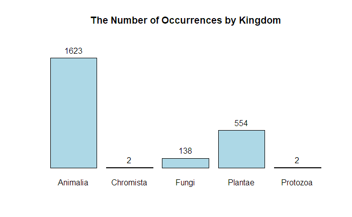

```r
# Create a barplot
kingdom_bp <- barplot(
  kingdoms_count,
  main = "The Number of Occurrences by Kingdom", # Title of the chart
  ylim = c(0, 1900), # The scale of the y a-xis
  yaxt = "n",
  col = "lightblue" # Column color
)

# Show the number of occurrences on the top of each column, with text is black.
text(x = kingdom_bp, y = kingdoms_count, label = kingdoms_count, pos = 3, col = "black")
```

We can see that Animalia is the most frequent, with **1623** occurrences.

## Create a quick plot() of your choice

I selected Fungi earlier, and I live in Atlantic City. Let’s get a subset of the Fungi kingdom in Atlantic City and then collect a few pictures of the top 5 commonly photographed species.

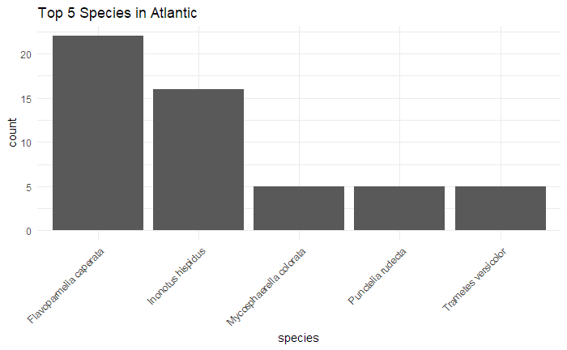

```r
# Get fungi kingdom in Atlantic
fungi_kingdom_in_atlantic_df <- iNaturalist_df[
  iNaturalist_df$kingdom == "Fungi" & iNaturalist_df$place_county_name == "Atlantic",
]

# Get top 5 species
top_5fungi_kingdom_in_atlantic <- fungi_kingdom_in_atlantic_df %>%
  group_by(species) %>%
  summarise(count = n()) %>%
  arrange(desc(count)) %>%
  slice(1:5)

# Count the number of occurrences of each species
species_count <- table(fungi_kingdom_in_atlantic_df$species)

# Create a bar chart with default settings
ggplot(
  top_5fungi_kingdom_in_atlantic,
  aes(x = species, y = count)
) +
  geom_bar(stat = "identity") + # Apply no statistic +
  labs(
    title = "Top 5 Species in Atlantic"
  ) +
  theme_minimal() +
  theme(
    axis.text.x = element_text(angle = 45, hjust = 1),
  )
```

```r
# Show the number of occurrences on the top of each column, with text is black.
#text(x = species_bp, y = species_count, label = species_count, pos = 3, col = "black")
```

So, it seems like “Flavoparmelia caperata” is the winner.

Let’s collect some pictures of this species from the data.

```r
pictures <- fungi_kingdom_in_atlantic_df[
  fungi_kingdom_in_atlantic_df$species == "Flavoparmelia caperata",
]$image_url

head(pictures, n = 3)
```

```
[1] "https://inaturalist-open-data.s3.amazonaws.com/photos/114855548/medium.jpg" "https://inaturalist-open-data.s3.amazonaws.com/photos/120802850/medium.jpg"
[3] "https://inaturalist-open-data.s3.amazonaws.com/photos/158153406/medium.jpg"
```

Copy and paste the image url:

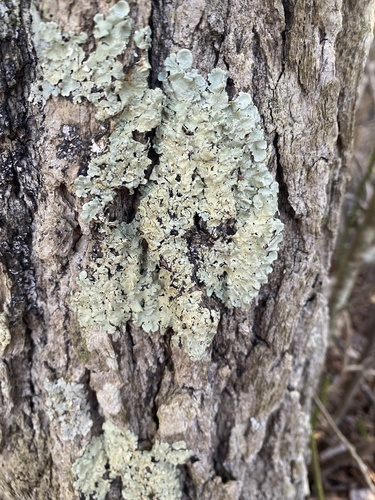

Flavoparmelia caperata 1

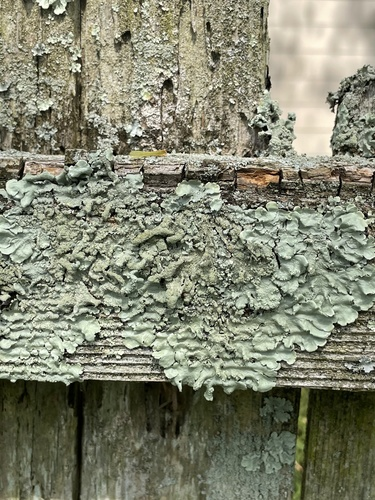

Flavoparmelia caperata 2

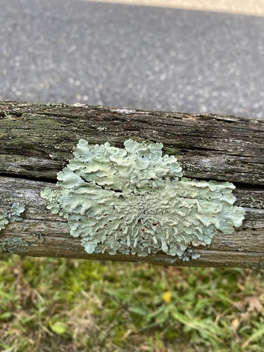

Flavoparmelia caperata 3

Very… interesting! 😝

## Save the new cleaned data frame as a new .csv file named “iNaturalist_ResearchGrade_YourLastName.csv”

Write to a new csv file with my last name Le:

```r
# Create a new file in the current working directory
write.csv(iNaturalist_df, paste0(getwd(), "/iNaturalist_ResearchGrade_Le.csv"))
```